# Logistic Regression: Noun or verb?

Jamie Reilly, Ph.D.

July 19, 2020

This session will cover Chapter 8 of the Field et al. text. We will focus on binary logistic regression (not polychotomous or multinomial)

```r
library(tidyverse)
library(car) #regression diagnostics, lots of other regression functions
library(broom) #tidies output
library(corrplot)
library(janitor) #cleans up character strings -- upper to lower, etc.=
library(ltm) #point biserial correlations
library(cocor) #contrasts two correlations
library(viridis) #color palette
library(caret) #order of importance of predictors
library(pscl) #derives pseudo R2 for logistic regression
library(stats) #for plog.is function
library(InformationValue)
jamie.theme <- theme_bw() + theme(axis.line = element_line(colour = "black"), panel.grid.minor = element_blank(), panel.grid.major = element_blank(), panel.border = element_blank(), panel.background = element_blank(), legend.title= element_blank())
```

# Introduction

We will be using a merged psycholinguistic database values for many psycholinguistic variables across many English words. We will examine the capacity to discriminate verb from noun given a set of variables (length, semantic density) Filter rows by POS – (brys_pos) - only nouns or verbs

```r
big <- read.csv("Reilly_LexDbases_Merged_v1.csv", header=T) %>% clean_names %>% data.frame()
iso <- big %>% filter(brys_pos == "Verb" | brys_pos == "Noun") #isolate nouns and verbs
iso$brys_pos <- as.factor(iso$brys_pos)
iso$elp_naming_rt <- as.numeric(iso$elp_naming_rt)
iso$elp_sem_neighbors <- as.numeric(iso$elp_sem_neighbors)
iso$elp_lex_dec_rt <- as.numeric(iso$elp_lex_dec_rt)
cbind(names(iso))
```

```
##       [,1]
##  [1,] "word"
##  [2,] "gls_nlett"
##  [3,] "gls_arousal"
##  [4,] "gls_valence"
##  [5,] "gls_dominance"
##  [6,] "gls_cnc"
##  [7,] "gls_img"
##  [8,] "gls_fam"
##  [9,] "gls_aoa"
## [10,] "gls_size"
## [11,] "gls_gender"
## [12,] "kup_pos"
## [13,] "kup_nlett"
## [14,] "kup_nphon"
```

[output cut: 28 more lines]

# Isolate Variables

Let’s focus on six predictors in no particular order of importance. We will create a smaller dataframe just with these predictors along with word and grammatical class, including:  
1. Total phonemes (kup_nphon)  
2. Semantic diversity (elp_sem_diversity)  
3. Lexical decision RT (elp_lex_dec_rt)  
4. Concreteness (brys_concreteness)  
5. Hand-Arm Salience (lnc_handarm)  
6. Age-of-Acquisition (kup_aoa)

```r
smaller <- iso %>% dplyr::select(1, 26, 14, 21, 22, 24, 34, 16) %>% data.frame()
colnames(smaller)
```

```
## [1] "word"              "brys_pos"          "kup_nphon"
## [4] "elp_sem_diversity" "elp_lex_dec_rt"    "brys_concreteness"
## [7] "lnc_handarm"       "kup_aoa"
```

# Exploration

## boxplot

Facetted boxplot across predictors by grammatical class, then corrplot among predictors

```r
long <- smaller %>% pivot_longer(c(3:8), names_to="variable", values_to="value") %>% data.frame()
head(long)
```

|  | word | brys_pos | variable | value |
| --- | --- | --- | --- | --- |
| 1 | abbreviate | Verb | kup_nphon | 8.000000 |
| 2 | abbreviate | Verb | elp_sem_diversity | NA |
| 3 | abbreviate | Verb | elp_lex_dec_rt | 795.032000 |
| 4 | abbreviate | Verb | brys_concreteness | 2.590000 |
| 5 | abbreviate | Verb | lnc_handarm | 2.105263 |
| 6 | abbreviate | Verb | kup_aoa | 9.950000 |

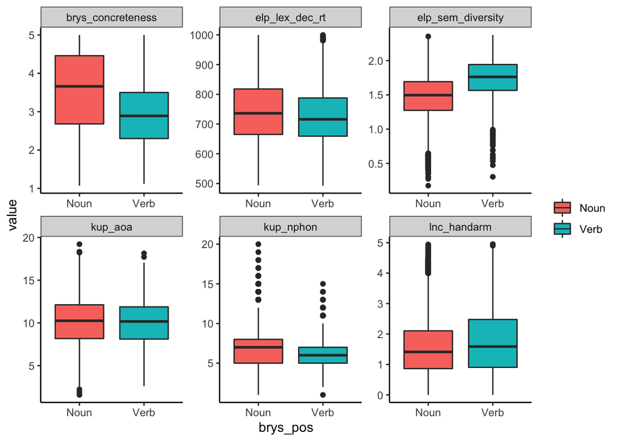

```r
ggplot(long, aes(brys_pos, value)) + geom_boxplot(aes(fill=brys_pos)) + facet_wrap(~variable, scales="free") + jamie.theme
```

## corrplot

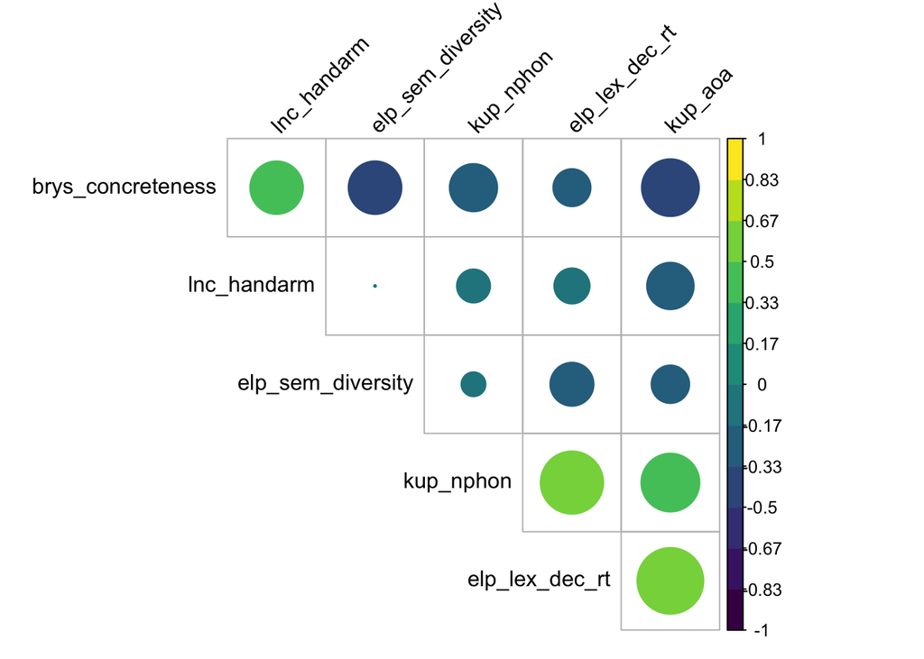

```r
setup <- smaller %>% dplyr::select(-1,-2)
bivar <- cor(setup, method="spearman", use="pairwise.complete.obs")
corrplot(bivar, method = "circle", type = "upper", tl.srt = 45, tl.cex = 1, col = viridis(12),
    tl.col = "black", diag = F, order = "hclust")
```

We’ll tackle PCA/factor reduction in a later session.

## sample bias

```r
table(smaller$brys_pos) # lots more nouns than verbs
```

```
##
##  Noun  Verb
## 14852  5379
```

# Construct models

## base model (mod0)

Intercept only model for examining deviance (lower is better)

```r
mod0 <- glm(brys_pos ~ 1, data=smaller, family = binomial())
summary(mod0)
```

```
##
## Call:
## glm(formula = brys_pos ~ 1, family = binomial(), data = smaller)
##
## Deviance Residuals:
##     Min       1Q   Median       3Q      Max
## -0.7862  -0.7862  -0.7862   1.6277   1.6277
##
## Coefficients:
##             Estimate Std. Error z value Pr(>|z|)
## (Intercept) -1.01563    0.01591  -63.82   <2e-16 ***
## ---
## Signif. codes:  0 '***' 0.001 '**' 0.01 '*' 0.05 '.' 0.1 ' ' 1
##
## (Dispersion parameter for binomial family taken to be 1)
##
##     Null deviance: 23432  on 20230  degrees of freedom
## Residual deviance: 23432  on 20230  degrees of freedom
## AIC: 23434
##
## Number of Fisher Scoring iterations: 4
```

## Full model (mod1)

Forced entry all predictors. Grammatical class as a function of 6 variables all in one block. glm is generalized linear model

```r
mod1 <- glm(brys_pos ~ kup_nphon + elp_sem_diversity + elp_lex_dec_rt + brys_concreteness + kup_aoa + lnc_handarm, data=smaller, family = binomial())
summary(mod1)
```

```
##
## Call:
## glm(formula = brys_pos ~ kup_nphon + elp_sem_diversity + elp_lex_dec_rt +
##     brys_concreteness + kup_aoa + lnc_handarm, family = binomial(),
##     data = smaller)
##
## Deviance Residuals:
##     Min       1Q   Median       3Q      Max
## -2.1052  -0.5543  -0.3252  -0.1544   3.2673
##
## Coefficients:
##                     Estimate Std. Error z value Pr(>|z|)
## (Intercept)       -1.9573508  0.4573493  -4.280 1.87e-05 ***
## kup_nphon         -0.4036030  0.0190043 -21.237  < 2e-16 ***
## elp_sem_diversity  2.2821836  0.1306126  17.473  < 2e-16 ***
## elp_lex_dec_rt     0.0032790  0.0004522   7.252 4.11e-13 ***
## brys_concreteness -1.0954671  0.0461068 -23.759  < 2e-16 ***
## kup_aoa           -0.0833371  0.0167920  -4.963 6.94e-07 ***
## lnc_handarm        0.5858688  0.0361221  16.219  < 2e-16 ***
## ---
## Signif. codes:  0 '***' 0.001 '**' 0.01 '*' 0.05 '.' 0.1 ' ' 1
##
## (Dispersion parameter for binomial family taken to be 1)
##
##     Null deviance: 8904.9  on 9643  degrees of freedom
## Residual deviance: 6696.1  on 9637  degrees of freedom
##   (10587 observations deleted due to missingness)
## AIC: 6710.1
##
## Number of Fisher Scoring iterations: 6
```

```r
tidy(mod1) #broom function
```

| term | estimate | std.error | statistic | p.value |
| --- | --- | --- | --- | --- |
| (Intercept) | -1.957350783 | 0.4573492786 | -4.279772 | 1.870846e-05 |
| kup_nphon | -0.403602969 | 0.0190042777 | -21.237480 | 4.303656e-100 |
| elp_sem_diversity | 2.282183587 | 0.1306125959 | 17.472921 | 2.303909e-68 |
| elp_lex_dec_rt | 0.003279003 | 0.0004521587 | 7.251884 | 4.110145e-13 |
| brys_concreteness | -1.095467058 | 0.0461067745 | -23.759351 | 8.795276e-125 |
| kup_aoa | -0.083337086 | 0.0167920293 | -4.962895 | 6.944996e-07 |
| lnc_handarm | 0.585868814 | 0.0361221218 | 16.219114 | 3.694856e-59 |

```r
exp(coef(mod1))  ## exponentiate log odds to odds ratio --
```

```
##       (Intercept)         kup_nphon elp_sem_diversity    elp_lex_dec_rt
##         0.1412321         0.6679092         9.7980520         1.0032844
## brys_concreteness           kup_aoa       lnc_handarm
##         0.3343834         0.9200410         1.7965512
```

#Fit Is the full model (mod1) better than the base model (mod0)? goal of logistic regression is to develop a model that minimizes deviance residuals. Models with a McFadden pseudo R2≈ 0.40 represents a very good fit.

```r
list(mod1 = pscl::pR2(mod1)["McFadden"])
```

```
## fitting null model for pseudo-r2
```

```
## $mod1
##  McFadden
## 0.2480425
```

# Prediction

## validation & test sets

```r
set.seed(123)
trainIndex <- createDataPartition(smaller$brys_pos, p=0.7, list=FALSE, times=1)  #sample 70% of each factor
train <- smaller[trainIndex,] %>% data.frame
str(train)
```

```
## 'data.frame':    14163 obs. of  8 variables:
##  $ word             : chr  "abbreviate" "abdicate" "abdomen" "abduct" ...
##  $ brys_pos         : Factor w/ 2 levels "Noun","Verb": 2 2 1 2 1 2 1 2 1 1 ...
##  $ kup_nphon        : int  8 7 7 6 8 4 7 6 8 5 ...
##  $ elp_sem_diversity: num  NA NA 1.23 NA 1.48 ...
##  $ elp_lex_dec_rt   : num  795 NA 813 770 796 ...
##  $ brys_concreteness: num  2.59 2.08 4.7 2.88 3.07 1.68 3.41 3.11 2.21 2.71 ...
##  $ lnc_handarm      : num  2.105 0.867 1.316 2.55 2.333 ...
##  $ kup_aoa          : num  9.95 12.6 8.61 11.26 11.94 ...
```

```r
test <- smaller[-trainIndex,] %>% data.frame
str(test)
```

```
## 'data.frame':    6068 obs. of  8 variables:
##  $ word             : chr  "ability" "abode" "abuser" "accelerate" ...
##  $ brys_pos         : Factor w/ 2 levels "Noun","Verb": 1 1 1 2 1 2 1 2 1 1 ...
##  $ kup_nphon        : int  7 4 6 8 8 5 5 7 4 6 ...
##  $ elp_sem_diversity: num  2.06 1.65 NA 1.83 1.19 ...
##  $ elp_lex_dec_rt   : num  620 856 NA 711 930 ...
##  $ brys_concreteness: num  1.81 3.92 3.86 3.48 4.86 2.25 4.96 2.97 4.57 4.54 ...
##  $ lnc_handarm      : num  2.55 1.31 2 1.17 3.44 ...
##  $ kup_aoa          : num  8.84 12.06 9.94 10.74 8.61 ...
```

## build models

### validation set

Let’s build models for the training set

```r
valid.set <- glm(brys_pos ~ kup_nphon + elp_sem_diversity + elp_lex_dec_rt + brys_concreteness + kup_aoa + lnc_handarm, data=train, family = binomial())  #model with all predictors
summary(valid.set)
```

```
##
## Call:
## glm(formula = brys_pos ~ kup_nphon + elp_sem_diversity + elp_lex_dec_rt +
##     brys_concreteness + kup_aoa + lnc_handarm, family = binomial(),
##     data = train)
##
## Deviance Residuals:
##     Min       1Q   Median       3Q      Max
## -2.1134  -0.5485  -0.3177  -0.1459   3.3197
##
## Coefficients:
##                     Estimate Std. Error z value Pr(>|z|)
## (Intercept)       -2.5935482  0.5481937  -4.731 2.23e-06 ***
## kup_nphon         -0.4057239  0.0228048 -17.791  < 2e-16 ***
## elp_sem_diversity  2.5448086  0.1591387  15.991  < 2e-16 ***
## elp_lex_dec_rt     0.0034251  0.0005381   6.365 1.95e-10 ***
## brys_concreteness -1.0650479  0.0545673 -19.518  < 2e-16 ***
## kup_aoa           -0.0792794  0.0200305  -3.958 7.56e-05 ***
## lnc_handarm        0.5567665  0.0429461  12.964  < 2e-16 ***
## ---
## Signif. codes:  0 '***' 0.001 '**' 0.01 '*' 0.05 '.' 0.1 ' ' 1
##
## (Dispersion parameter for binomial family taken to be 1)
##
##     Null deviance: 6262.6  on 6765  degrees of freedom
## Residual deviance: 4648.8  on 6759  degrees of freedom
##   (7397 observations deleted due to missingness)
## AIC: 4662.8
##
## Number of Fisher Scoring iterations: 6
```

```r
exp(coef(valid.set))  #converts log odds to odds ratios
```

```
##       (Intercept)         kup_nphon elp_sem_diversity    elp_lex_dec_rt
##        0.07475433        0.66649417       12.74078986        1.00343101
## brys_concreteness           kup_aoa       lnc_handarm
##        0.34471134        0.92378181        1.74502087
```

```r
list(valid.set = pscl::pR2(valid.set)["McFadden"])  #generate model fir mcfadden pseudo R
```

```
## fitting null model for pseudo-r2
```

```
## $valid.set
##  McFadden
## 0.2576799
```

## prediction in test set

Compute accuracy of the classification of noun or verb on the testing set

```r
pred <- predict(valid.set, test, type="response", na.action = na.pass)
```

## prediction error

computes prediction error of the model in the test set

```r
misClassError(test$brys_pos, pred)  #computes prediction error as %
```

```
## [1] 0.4743
```

# Diagnostics

## multicollinearity

Variance inflation factor (VIF) should be below 4

```r
vif(valid.set)  # not bad at all
```

```
##         kup_nphon elp_sem_diversity    elp_lex_dec_rt brys_concreteness
##          1.593722          1.231209          1.881988          2.017313
##           kup_aoa       lnc_handarm
##          2.041089          1.381721
```